# hw7

# Exercise 5.3

## (a)

將有罹患肺癌的人隨機抽樣分成兩群：有吸菸群及沒吸菸群；並觀察兩者人群中罹患肺癌的原因，進而得出關係。

## (b)

這是observational data，因為我們是藉由人群分類得出兩者差異並非設計實驗控制變因來得到資料。

# Exercise 5.9

因為報紙要得到該調查資料需要有兩個條件： 1.這則資料會讓未擁有email的人不會收到問題，因此存在selction bias 2.對這個問題有興趣有想法的人才會回復，因此存在self-selection bias 因此這則統計資料存在問題，故我們可以忽略它

# Exercise 5.13

使用cluster sampling 分成四群進行抽樣，依照三者學院學生以及總學生扣除三者學院學生的數量，依比例分配4群的樣本數；觀察三者學院以及扣除三者學院的總學生樣本+三者學院樣本(=總學生樣本)進行比較得到結論。

# Exercise 5.19

不可能。因為對於sample而言會有和母體間的sample error，因此若有辦法擷取母體的資料，效果絕對會比採樣更好(因為不會有誤差)

```r
x <- read.csv("C:\\Users\\ultim\\Downloads\\Stat_HW_CH5_sampling_A1 (1).csv")
attach(x)
```

# Exercise A1

## 1

求出母體的平均數及變異數

```r
mean = mean(Fruit.and.Vegetables)
mean
```

```
[1] 3.644421
```

此為母體的平均數

```r
Flength = length(Fruit.and.Vegetables)
varp = var(Fruit.and.Vegetables)*(Flength-1)/(Flength)
varp
```

```
[1] 0.7163822
```

此為母體調整前的變異數

```r
vars = var(Fruit.and.Vegetables)
vars
```

```
[1] 0.7164121
```

此為母體調整後的變異數

## 2

求出在set.seed(32535)下採樣240筆資料的樣本平均數及變異數

```r
set.seed(32535)
samF <- sample(Fruit.and.Vegetables,240)
mean(samF)
```

```
[1] 3.567917
```

這是在set.seed(32535)的情況下採樣240筆資料所求出的平均數

```r
set.seed(32535)
samF <- sample(Fruit.and.Vegetables,240)
varTFT = var(samF)
varTFT
```

```
[1] 0.7642802
```

## 3

求出樣本誤差的絕對值

```r
abs(mean(samF)-mean)
```

```
[1] 0.07650417
```

```r
abs(varp - varTFT)
```

```
[1] 0.04789795
```

和調整前的變異數相減所得的樣本誤差

```r
abs(vars - varTFT)
```

```
[1] 0.0478681
```

和調整後的變異數相減所得的樣本誤差

由上述數值可知，樣本變異數和調整後的變異數相減所得的樣本誤差較小

## 4

得出題目所要求的三者的RMSE

```r
meanRMSE = vector(mode = "numeric", length = 1000)
set.seed(1118)
for (i in 1:1000) {
 samF <- sample(Fruit.and.Vegetables,240)
 m2 = mean(samF)
 meanRMSE[i] = (m2- mean)*(m2- mean)
}
sumMean = sqrt(sum(meanRMSE)/1000)
sumMean
```

```
[1] 0.05383188
```

這是Mean的RMSE，經由for迴圈跑一千次採樣步驟得到1000組不同的mean，再把這些各自的mean和母體mean想減並平方再求平均之後開根號得到答案

```r
varRMSE = vector(mode = "numeric", length = 1000)
set.seed(1118)
for (i in 1:1000) {
 samF <- sample(Fruit.and.Vegetables,240)
 m3 = var(samF)
 varRMSE[i] = (m3- varp)*(m3- varp)
}
sumVar = sqrt(mean(varRMSE))
sumVar
```

```
[1] 0.06491507
```

和mean的RMSE算法概念大致相同，但將需要改成調整前變異數的地方改掉。

```r
varRMSE = vector(mode = "numeric", length = 1000)
set.seed(1118)
for (i in 1:1000) {
 samF <- sample(Fruit.and.Vegetables,240)
 m3 = var(samF)
 varRMSE[i] = (m3- vars)*(m3- vars)
}
sumVar = sqrt(mean(varRMSE))
sumVar
```

```
[1] 0.06491478
```

和mean的RMSE算法概念大致相同，但將需要改成調整後變異數的地方改掉。

經由1000次採樣求得的RMSE和只做1次採樣所得的誤差相筆(0.07650417)，RMSE的值較小，可以顯示經由愈多次採樣後所得的誤差越來越小 調整前後兩者的RMSE相比，可看出調整後的RMSE誤差值較小，這點和3的誤差結論相同

## 5

```r
Fruit_list = matrix(nrow=11,ncol=200)
sizelist = c(10, 20, 40, 80, 160, 320, 640, 1280, 2560, 5120, 12800)
varlist = c()
for ( i in c(1:11))
{
  for ( j in c(1:200))
  {
    size = sizelist[i]
    ind1 = sample(Fruit.and.Vegetables, size,replace=TRUE)

    m = mean(ind1)
    Fruit_list[i,j] = m
  }
  varlist[i] = var(Fruit_list[i,])
  cat("The variance of the mean of 200 repetitions of sample size ",sizelist[i]," is:" ,var(Fruit_list[i,]),"\n")
}
```

```
The variance of the mean of 200 repetitions of sample size  10  is: 0.08299574
The variance of the mean of 200 repetitions of sample size  20  is: 0.03701931
The variance of the mean of 200 repetitions of sample size  40  is: 0.01892487
The variance of the mean of 200 repetitions of sample size  80  is: 0.008764352
The variance of the mean of 200 repetitions of sample size  160  is: 0.003734734
The variance of the mean of 200 repetitions of sample size  320  is: 0.002498948
The variance of the mean of 200 repetitions of sample size  640  is: 0.0009769594
The variance of the mean of 200 repetitions of sample size  1280  is: 0.0005633029
The variance of the mean of 200 repetitions of sample size  2560  is: 0.0003371259
The variance of the mean of 200 repetitions of sample size  5120  is: 0.0001445306
The variance of the mean of 200 repetitions of sample size  12800  is: 5.605081e-05
```

```r
library("ggplot2")
str(Fruit.and.Vegetables)
```

```
 num [1:24000] 4.6 3.3 4.9 4.4 3.7 3 3.5 2.9 2.7 3 ...
```

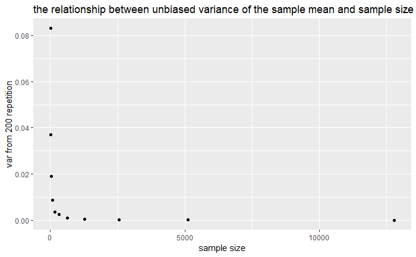

```r
qplot(sizelist, varlist, xlab= "sample size", ylab = "var from 200 repetition", main = "the relationship between unbiased variance of the sample mean and sample size")
```

經由越多次的樣本採計(sample size) 並配合圖表，我們可以看出unbiased variance隨著樣本數的增加越來越低